# Unit6CaseStudy_TidyData

Oscar Padilla

June 13, 2016

# GDP Ranking and Income Group Analysis

### CASE STUDY FOR UNIT 6 - *Tidy Data*

## I. Introduction

The following analysis was developed using GDP Ranking Data from THE WORLD BANK, which includes 190 economies ranked from the largest (the USA) to the smallest (Tuvalu). This file was complemented by adding the Income Group found in the Education Statistics file from the same institution. This analysis aims to answer the question, what is the relation between the size of an economy and the standard of living of its citizens as represented by their income level.

## II. Data import and cleansing

As explained in the README file, the following libraries are required. The subsequent code downloads the GDP file and prepares this first data set for merger.

```r
library(repmis)
library(dplyr)
library(ggplot2)
library(reshape2)
library(countrycode)
library(RCurl)
GDPurl <- "https://d396qusza40orc.cloudfront.net/getdata%2Fdata%2FGDP.csv"
rawGDP <- source_data(GDPurl, sep = ",", header = FALSE, stringsAsFactors = TRUE)
```

```
## SHA-1 hash of the downloaded data file is:
## 18dd2f9ca509a8ace7d8de3831a8f842124c533d
```

```r
#Eliminate header and footer non-variable information
rawGDP <- rawGDP[6:195, ]
#Select only valid variables
GDPSelected <- dplyr::select(rawGDP, V1, V2, V4, V5)
#Rename variables to be human readable
names(GDPSelected) <- c("country_short", "rank", "country_long", "GDP2012")
#Look for NA values
GDPSelected[is.na(GDPSelected$GDP2012), ]
```

```
## [1] country_short rank          country_long  GDP2012
## <0 rows> (or 0-length row.names)
```

```r
#Convert GDP into a numeric variable
GDPSelected$GDP2012 <- as.numeric(gsub(",", "", GDPSelected$GDP2012))
#Sort the data frame in ascending order by GDP (so United States is last). What is the 13th country in the resulting data frame
GDPclean <- arrange(GDPSelected, GDP2012)
GDPclean <- rename(GDPclean, CountryCode = country_short)
str(GDPclean)
```

```
## 'data.frame':    190 obs. of  4 variables:
##  $ CountryCode : Factor w/ 229 levels "","ABW","ADO",..: 209 107 135 164 189 70 205 53 43 224 ...
##  $ rank        : Factor w/ 196 levels "",".. Not available.",..: 103 101 100 99 98 97 96 95 94 93 ...
##  $ country_long: Factor w/ 230 levels "","Afghanistan",..: 213 106 133 159 201 137 207 56 44 172 ...
##  $ GDP2012     : num  40 175 182 228 263 326 472 480 596 684 ...
```

```r
#Top ten economies in descending order (largest economy first)
arrange(tail(GDPclean, 10), desc(GDP2012))
```

```
##    CountryCode rank       country_long  GDP2012
## 1          USA    1      United States 16244600
## 2          CHN    2              China  8227103
## 3          JPN    3              Japan  5959718
## 4          DEU    4            Germany  3428131
## 5          FRA    5             France  2612878
## 6          GBR    6     United Kingdom  2471784
## 7          BRA    7             Brazil  2252664
## 8          RUS    8 Russian Federation  2014775
## 9          ITA    9              Italy  2014670
## 10         IND   10              India  1841710
```

```r
#Last 13 countries by GDP size (smallest economy first)
head(GDPclean, 13)
```

```
##    CountryCode rank                   country_long GDP2012
## 1          TUV  190                         Tuvalu      40
## 2          KIR  189                       Kiribati     175
## 3          MHL  188               Marshall Islands     182
## 4          PLW  187                          Palau     228
## 5          STP  186    S\xe3o Tom\xe9 and Principe     263
## 6          FSM  185          Micronesia, Fed. Sts.     326
## 7          TON  184                          Tonga     472
## 8          DMA  183                       Dominica     480
## 9          COM  182                        Comoros     596
## 10         WSM  181                          Samoa     684
## 11         VCT  180 St. Vincent and the Grenadines     713
## 12         GRD  178                        Grenada     767
## 13         KNA  178            St. Kitts and Nevis     767
```

## III. Q&A Section

Note: Question 1, which will be addressed in a later section

#### Question 2. Sort the data frame in ascending order by GDP rank (so United States is last). What is the 13th country in the resulting data frame?

*The 13th country is St. Kitts and Nevis with a GDP of $ 767 million USD.*

The Education Statistics data set provides the Income Group required for further analysis and the Country Code is used to link it with the GDP data frame.

```r
EduURL <- "https://d396qusza40orc.cloudfront.net/getdata%2Fdata%2FEDSTATS_Country.csv"
rawEdu <- source_data(EduURL, sep = ",", header = TRUE, stringsAsFactors = TRUE)
```

```
## SHA-1 hash of the downloaded data file is:
## 20be6ae8245b5a565a815c18a615a83c34745e5e
```

```r
#Select variables (columns) we actually need: first Country Code and third Income Group
EduSelected <- select(rawEdu, 1, 3)
names(EduSelected)[2] <- "IncomeGroup"
str(EduSelected)
```

```
## 'data.frame':    234 obs. of  2 variables:
##  $ CountryCode: Factor w/ 234 levels "ABW","ADO","AFG",..: 1 2 3 4 5 6 7 8 9 10 ...
##  $ IncomeGroup: Factor w/ 6 levels "","High income: OECD",..: 3 3 4 5 6 3 6 5 6 6 ...
```

Once we have cleaned up both files, let’s proceed to merge both data sets.

```r
GDPEdu <- merge(GDPclean, EduSelected, by = "CountryCode", all = TRUE)
```

#### Question 3. What are the average GDP rankings for the “High income: OECD” and “High income: nonOECD” groups?

In order to answer the question above, we need to first convert the variable *rank_num* into a numeric variable in order to be able to compute the mean and select the respective Income Groups.

```r
GDPEduSelected <- GDPEdu[!is.na(GDPEdu$GDP2012), ]
GDPEduclean <- arrange(GDPEduSelected, desc(GDP2012))
GDPEduclean$rank_num <- as.numeric(as.character(GDPEduclean$rank))
attach(GDPEduclean)
GDPEduclean[!is.na(GDPEduclean$IncomeGroup) & GDPEduclean$IncomeGroup == "High income: OECD", ]
```

```
##     CountryCode rank    country_long  GDP2012       IncomeGroup rank_num
## 1           USA    1   United States 16244600 High income: OECD        1
## 3           JPN    3           Japan  5959718 High income: OECD        3
## 4           DEU    4         Germany  3428131 High income: OECD        4
## 5           FRA    5          France  2612878 High income: OECD        5
## 6           GBR    6  United Kingdom  2471784 High income: OECD        6
## 9           ITA    9           Italy  2014670 High income: OECD        9
## 11          CAN   11          Canada  1821424 High income: OECD       11
## 12          AUS   12       Australia  1532408 High income: OECD       12
## 13          ESP   13           Spain  1322965 High income: OECD       13
## 15          KOR   15     Korea, Rep.  1129598 High income: OECD       15
## 18          NLD   18     Netherlands   770555 High income: OECD       18
## 20          CHE   20     Switzerland   631173 High income: OECD       20
## 21          SWE   21          Sweden   523806 High income: OECD       21
## 23          NOR   23          Norway   499667 High income: OECD       23
```

[output cut: 16 more lines]

```r
# Average GDP rankings for the "High income: OECD"
mean(GDPEduclean[!is.na(GDPEduclean$IncomeGroup) & GDPEduclean$IncomeGroup == "High income: OECD", 6])
```

```
## [1] 32.96667
```

```r
GDPEduclean[!is.na(GDPEduclean$IncomeGroup) & GDPEduclean$IncomeGroup == "High income: nonOECD", ]
```

```
##     CountryCode rank         country_long GDP2012          IncomeGroup
## 19          SAU   19         Saudi Arabia  711050 High income: nonOECD
## 32          ARE   32 United Arab Emirates  348595 High income: nonOECD
## 35          SGP   35            Singapore  274701 High income: nonOECD
## 37          HKG   37 Hong Kong SAR, China  263259 High income: nonOECD
## 54          QAT   54                Qatar  171476 High income: nonOECD
## 56          KWT   56               Kuwait  160913 High income: nonOECD
## 61          PRI   61          Puerto Rico  101496 High income: nonOECD
## 66          OMN   66                 Oman   69972 High income: nonOECD
## 71          HRV   71              Croatia   59228 High income: nonOECD
## 82          MAC   82     Macao SAR, China   43582 High income: nonOECD
## 93          BHR   93              Bahrain   29044 High income: nonOECD
## 94          LVA   94               Latvia   28373 High income: nonOECD
## 101         TTO  101  Trinidad and Tobago   23320 High income: nonOECD
## 102         CYP  102               Cyprus   22767 High income: nonOECD
```

[output cut: 33 more lines]

```r
# Average GDP rankings for the "High income: nonOECD"
mean(GDPEduclean[!is.na(GDPEduclean$IncomeGroup) & GDPEduclean$IncomeGroup == "High income: nonOECD", 6])
```

```
## [1] 91.91304
```

#### Question 4. Plot the GDP for all of the countries. Use ggplot2 to color your plot by Income Group.

Given the enormous GDP range (e.g. from 16 trillion to 40 million), log base 10 is a better representation of the GDP variable.

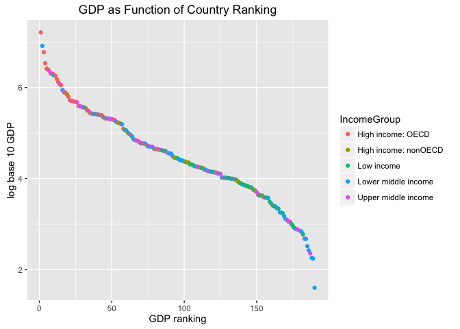

```r
ggplot(data = GDPEduclean, aes(x = rank_num, y = log10(GDP2012))) + geom_point(aes(col = IncomeGroup)) + labs(title = "GDP as Function of Country Ranking", size = 20, face = "bold", x = "GDP ranking", y = "log base 10 GDP")+ scale_fill_manual(breaks = 50, 100, 150, 200, 250)
```

The chart matrix below clearly shows that there is a cluster of High Income: OECD countries on the high GDP values (e.g. large economies), as opposed to the Lower middle income category covering the whole GDP spectrum. On the same token small economies correlate to Low income countries.

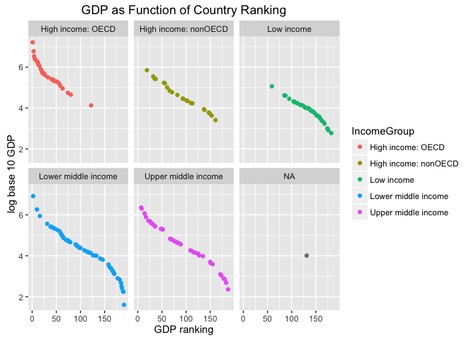

```r
ggplot(data = GDPEduclean, aes(x = rank_num, y = log10(GDP2012))) + geom_point(aes(col = IncomeGroup)) + labs(title = "GDP as Function of Country Ranking", x = "GDP ranking", y = "log base 10 GDP")+ scale_fill_manual(breaks = 50, 100, 150, 200, 250) + facet_wrap(~IncomeGroup)
```

Trying to plot ALL 190 country (short) names gets unwieldy and difficult to read. Thus, a random group of only 50 countries was plotted.

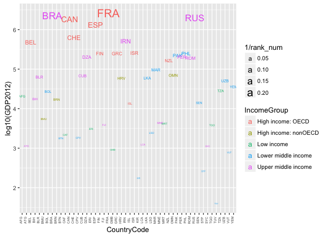

```r
RandomSampleofCountries <- sample(1:190, 50)
GDPEducleanSample <- GDPEduclean[RandomSampleofCountries, ]
ggplot(data = GDPEducleanSample, aes(x = CountryCode, y = log10(GDP2012))) + geom_text(aes(label = CountryCode, col = IncomeGroup, size = 1/rank_num)) + theme(axis.text.x = element_text(angle = 90, size = 5, vjust = 0))
```

##### Top-38 Economies

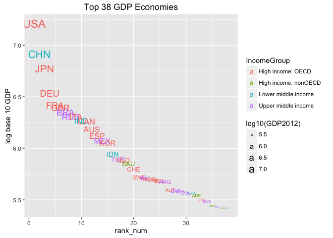

```r
Top38_GDPEduclean <- head(GDPEduclean, 38)
ggplot(data = Top38_GDPEduclean, aes(rank_num, log10(GDP2012))) + geom_text(aes(label = CountryCode, col = IncomeGroup, size = log10(GDP2012))) + labs(title = "Top 38 GDP Economies", y = "log base 10 GDP")
```

##### Bottom-38 Economies

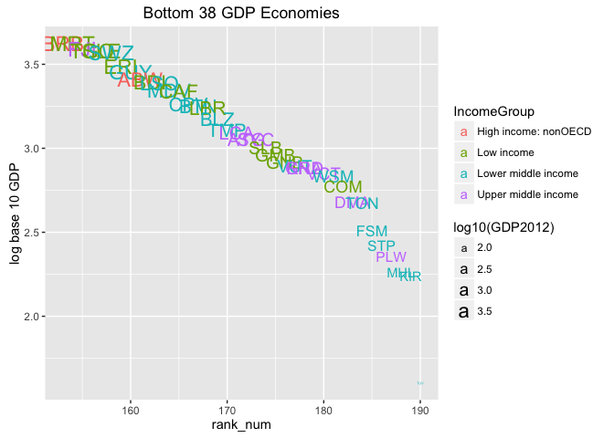

```r
Bottom38_GDPEduclean <- tail(GDPEduclean, 38)
ggplot(data = Bottom38_GDPEduclean, aes(rank_num, log10(GDP2012))) + geom_text(aes(label = CountryCode, col = IncomeGroup, size = log10(GDP2012))) + labs(title = "Bottom 38 GDP Economies", y = "log base 10 GDP")
```

#### Question 5. Cut the GDP ranking into 5 separate quantile groups. Make a table versus Income.Group. How many countries are Lower middle income but among the 38 nations with highest GDP?

The following code creates 5 symmetrical groups (38 countries each) based on GDP ranking. 1 being the group with the largest economies and group 5 the one with the smallest countries by GDP ranking.

```r
GDPEduclean$rank_quant <- cut(GDPEduclean$rank_num, breaks = 5, labels = FALSE)
GDPEducleanPivot <- acast(GDPEduclean, rank_quant ~ IncomeGroup)
GDPEducleanPivot
```

```
##   High income: OECD High income: nonOECD Low income Lower middle income
## 1                18                    4          0                   5
## 2                10                    5          1                  13
## 3                 1                    8          9                  12
## 4                 1                    4         16                   8
## 5                 0                    2         11                  16
##   Upper middle income NA
## 1                  11  0
## 2                   9  0
## 3                   8  0
## 4                   8  1
## 5                   9  0
```

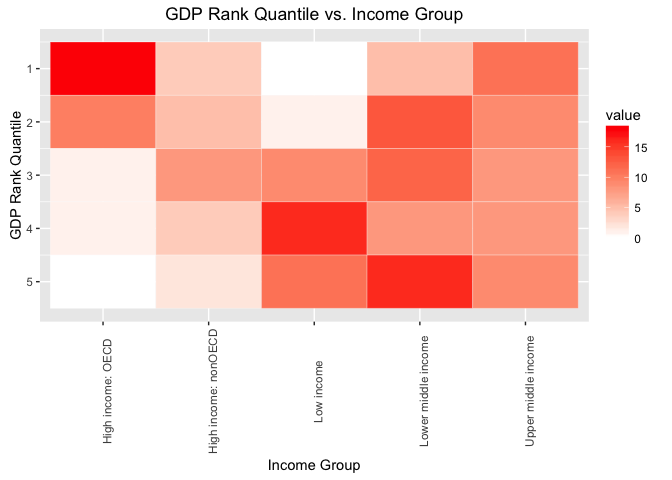

```r
GDPEducleanMelt <- melt(GDPEducleanPivot)
GDPEducleanMelt <- GDPEducleanMelt[1:25, ]
ggplot(data = GDPEducleanMelt, aes(x = Var2, y = Var1)) + scale_y_reverse() + geom_tile(data = GDPEducleanMelt, aes(fill = value), color = "white") + scale_fill_gradient2(low = "white", high = "red", limit = c(0, 18)) + labs(title = "GDP Rank Quantile vs. Income Group", x = "Income Group", y = "GDP Rank Quantile") + theme(axis.text.x = element_text(angle = 90))
```

*Only 5 countries are Lower middle income AND also belong to the top GDP ranking quantile*

The density matrix above clearly confirms our statements, High Income OECD countries overwhelming presence in the first quantile and on the other side of the spectrum Low and Lower Middle Income economies heavy presence in the lower quantiles.

## IV. Conclusions

- How many countries are there? The World Bank effectively produces 2012 GDP data for 190 countries.
- The difference in the size of the economies is abysmal: from the largest -trillions- to the smallest -millions.
- The Organization for Economic Cooperation and Development OECD is comprised mainly by rich (high income) and large countries (high GDP).
- Rich non-OECD countries tend to be middle size economies.
- Poor (low income) countries are also small (at the bottom of the ranking) -no low income countries belong to the top 20% of GDP ranking.
- The initial analysis carried out does not provide overwhelming evidence to conclude that larger economies are better off. Upper middle income and lower middle income economies are widespread in the GDP ranking spectrum. Further analysis is necessary including other variables, such as, GDP per capita, as well as, purchasing power parity (PPP), life expectancy, just to name a few, in order to draw conclusions of standard of living in function of GDP.